# Assignment 1: Decision trees and cost-effectiveness

Author

Huzbah Jagirdar

Published

January 17, 2023

# Section 1: Decision trees

We’ll use the [rdecision package](https://cran.r-project.org/web/packages/rdecision/index.html) to develop and visualize decision trees. There are multiple vignettes on the CRAN page; [this introductory one](https://cran.rstudio.com/web/packages/rdecision/vignettes/DT00-DecisionTreeTutorial.html) will probably be sufficient for how we use the package in this assignment.

## 1a Expected value calculations

This first code chunk is just an example; you don’t need to edit it. Here, using the rdecision package, I have created a decision tree, visualized it, and “roll it back” to calculate the expected cost and QALYs associated with the two strategies. Review it carefully, because in 1b, you’ll do similar calculations for a different decision tree.

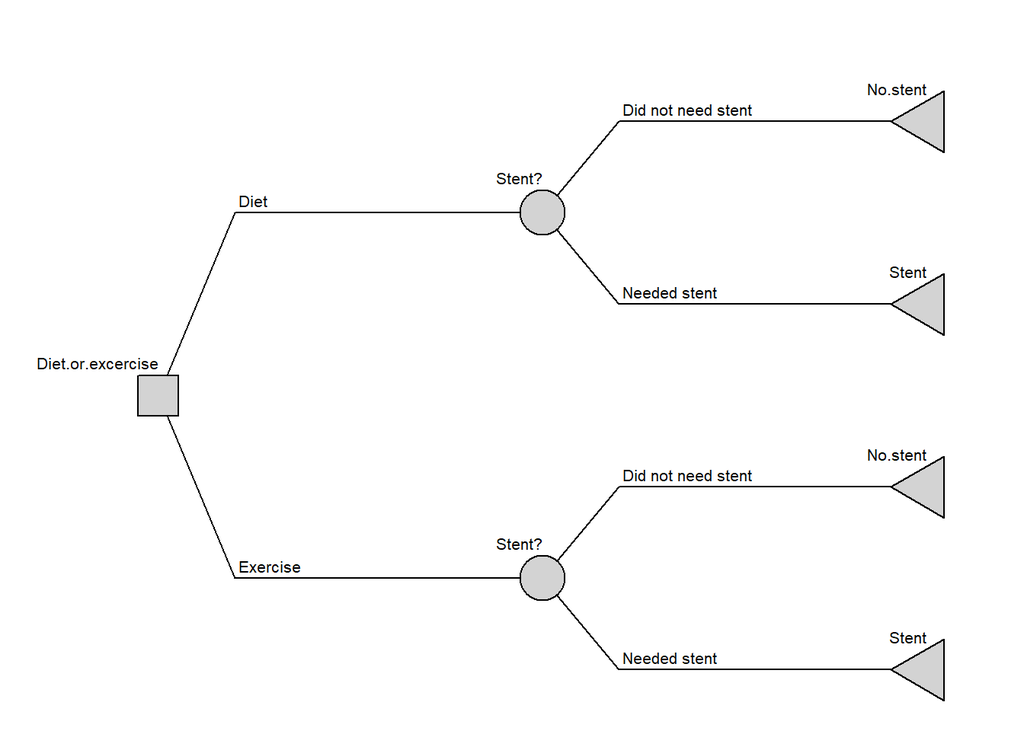

```r
#Use install.packages("XXXX") if you don't have any of these installed
library(rdecision) #decision trees
library(flextable) #Formatting tables to display (https://davidgohel.github.io/flextable/reference/index.html)
library(ggplot2) #Plotting
library(readxl) #for read_excel()
library(dplyr) # I use mutate at one point
theme_set(theme_bw()) #Makes ggplots look better

# Decision problem: Should we use diet or excercise to reduce chance of needing a stent in a high-risk population?

# Parameters
c_diet <- 50 #cost of diet
c_excercise <- 750 #cost of exercise
c_stent <- 5000 #cost of a stent
u_stent <- 0.75 #utility of getting a stent (relative to 1.0)
p_stent_diet <- (68 - 12)/68 #probability needing stent if we diet
p_stent_exercise <- (58 - 18)/58 #probability of needing a stent if we exercise

#Build model using rdecision package

#Create decision and chance nodes
decision_node <- DecisionNode$new("Diet or excercise")
chance_node_diet <- ChanceNode$new("Stent?")
chance_node_exercise <- ChanceNode$new("Stent?")

#Create leaf nodes
leaf_node_diet_no_stent <- LeafNode$new("No stent")
leaf_node_diet_stent <- LeafNode$new("Stent", utility = u_stent)
leaf_node_exercise_no_stent <- LeafNode$new("No stent")
leaf_node_exercise_stent <- LeafNode$new("Stent", utility = u_stent)

#Create 'actions', paths from your decision node(s)
action_diet <- Action$new(
  decision_node, chance_node_diet, cost = c_diet, label = "Diet"
)
action_exercise <- Action$new(
  decision_node, chance_node_exercise, cost = c_excercise, label = "Exercise"
)

#Create 'reactions', paths from your chance node(s)
reaction_diet_success <- Reaction$new(
  chance_node_diet, leaf_node_diet_no_stent,
  p = 1-p_stent_diet, cost = 0.0, label = "Did not need stent")

reaction_diet_failure <- Reaction$new(
  chance_node_diet, leaf_node_diet_stent,
  p = p_stent_diet, cost = c_stent, label = "Needed stent")

reaction_exercise_success <- Reaction$new(
  chance_node_exercise, leaf_node_exercise_no_stent,
  p = 1-p_stent_exercise, cost = 0.0, label = "Did not need stent")

reaction_exercise_failure <- Reaction$new(
  chance_node_exercise, leaf_node_exercise_stent,
  p = p_stent_exercise, cost = 5000.0, label = "Needed stent")

#Create, draw, and evaluate the tree
DT1 <- DecisionTree$new(
  V = list(decision_node, #verticies (nodes)
           chance_node_diet,
           chance_node_exercise,
           leaf_node_diet_no_stent,
           leaf_node_diet_stent,
           leaf_node_exercise_no_stent,
           leaf_node_exercise_stent),
  E = list(action_diet, #edges (paths between nodes)
           action_exercise,
           reaction_diet_success,
           reaction_diet_failure,
           reaction_exercise_success,
           reaction_exercise_failure)
)

DT1$draw() #Plot it
```

```r
DT1_evaluation <- DT1$evaluate() #calculate it
DT1_evaluation |> flextable()
```

| Diet.or.excercise | Run | Probability | Cost | Benefit | Utility | QALY |
| --- | --- | --- | --- | --- | --- | --- |
| Diet | 1 | 1 | 4,167.647 | 0 | 0.7941176 | 0.7941176 |
| Exercise | 1 | 1 | 4,198.276 | 0 | 0.8275862 | 0.8275862 |

mIn the code chunk below, using the variables defined in the last code chunk (e.g., `p_stent_diet`), calculate the expected utility and expected cost of the diet arm without using the `rdecision` package (simple summing/multiplying).

```r
expected_cost_diet <- c_diet+ p_stent_diet*c_stent

expected_utility_diet <- u_stent*p_stent_diet + 1*(1-p_stent_diet)


#Print the values
expected_cost_diet
```

```
[1] 4167.647
```

```r
expected_utility_diet
```

```
[1] 0.7941176
```

## 1b Peptic ulcer closure decision model

You will now develop a decision analysis to inform whether a newer clip should be used to close bleeding peptic ulcers in the gastrointestinal tract during an upper GI endocoscopy, which is also called an EGD (stands for esophagogastroduodenoscopy). The newer clips are called over-the-scope clips, abbreviated OTSc. Randomized trial data show that rebleeding rates are lower following endoscopic closure with OTSc as compared to when standard therapy clips are used, but OTSc are significantly more expensive. You will build a decision tree to determine whether OTSc are ‘worth’ the added expense, either as a first line therapy (i.e. to treat all peptic ulcer bleeds initially) or only for rebleeds (i.e. only if a standard therapy clip failed, resulting in a ‘rebleed’).

We assume all peptic ulcer bleeds are fully resolved during a short hospitalization; we therefore use a time horizon of only 30 days. No discounting is needed due to the short time horizon. Because this analysis involves very small differences in utility, our parameters are in quality-adjusted life days (QALDs) instead of quality-adjusted life years (QALYs); 1 QALD = 1/365 QALY.

All model parameters are provided for you in the “OTSc” sheet of the excel file `params_assign1.xlsx`, feel free to open it to take a look. For your assignment to render without error, this .qmd file and that .xlsx file must be in the same folder. The next chunk of code reads in the .xlsx file and generates a parameter table, using the flextable package for formatting (you don’t have to do anything in this code chunk).

NOTE: You might need to close the Excel file for the read_excel function to run properly.

```r
#read table from Excel
t_params <- read_excel('params_assign1.xlsx', sheet = "OTSc")
#Display it nicely
t_params |>
  flextable() |> #turn into flextable object
  merge_v(j=1) |> #Merge cells in first column with same value (group probabilities, costs, etc.)
  theme_box() |> #Apply a theme for aesthetics
  autofit() #automatically set column widths to reasonable values
```

| category | name | description | base_case | lower_bound | upper_bound |
| --- | --- | --- | --- | --- | --- |
| Probability | p_ST_rebleed | Continued bleding after an initial EGD using standard therapy clip | 0.110 | 0.080 | 0.14 |
|  | p_OTSc_rebleed | Continued bleding after an initial EGD using OTSc | 0.053 | 0.007 | 0.09 |
|  | p_ST_rpt_IR | Interventional Radiology (IR) procedure needed after second line EGD using standard therapy | 0.576 | 0.390 | 0.76 |
|  | p_OTSc_rpt_IR | Interventional Radiology (IR) procedure needed after second line EGD using OTSc | 0.152 | 0.030 | 0.27 |
| Cost | c_EGD_MD | EGD physician fee (CPT code) | 192.990 | 100.000 | 1,000.00 |
|  | c_STclip | Cost of standard therapy clip | 174.000 | 50.000 | 610.00 |
|  | c_OTSclip | Cost of over-the-scope clip | 438.000 | 170.000 | 1,000.00 |
|  | c_hosp_noCC | Hospitalization cost of single successful EGD, based on DRG 379: GI hemorrhage hospitalization w/o CC | 5,534.110 | 2,500.000 | 7,500.00 |
|  | c_hosp_CC | Hospitalization cost of needing two EGDs, based on DRG 377, GI hemorrhage hospitalization w/ CC | 7,503.890 | 5,500.000 | 13,000.00 |
|  | c_hosp_MCC | Hospitalization cost of two failed EGDs followed by an interventional radiology procedure, based on, DRG 378, GI hemorrhage hospitalization w/ MCC | 13,097.080 | 7,503.890 | 25,000.00 |
|  | c_IR_MD | Interventional radiology physician fee | 1,005.310 | 200.000 | 2,000.00 |
| QALY | q_single_EGD | QALYs experienced in one-year period if single EGD needed (loss of 4.75 quality-adjusted life days) | 0.987 | 0.984 | 1.00 |
|  | q_double_EGD | QALYs experienced in one-year period if two EGDs needed (1.1 quality-adjusted life days) | 0.984 | 0.970 | 1.00 |
|  | q_IR | QALYs experienced in one-year period if two EGDs and an IR procedure needed (3.65 quality-adjusted life days) | 0.974 | 0.939 | 1.00 |

In the code chunk below, build the model using the rdecision package with the ‘base_case’ value for each parameter (we won’t be using the ‘lower_bound’ or ‘upper_bound’ columns for anything in this problem set).

Your model should start with a decision node with three options:

- **OTSc first:** use OTS clip for first line therapy; if a rebleed occurs use a standard clip for second line therapy
- **ST first:** use a standard clip for first line therapy; if a rebleed occurs use an OTS clip for second line therapy
- **ST only**: use a standard clip for first line therapy and, if a rebleed occurs, for second line therapy.

All three arms from this decision node (“actions” in the rdecision package) will end at a chance node corresponding to the outcomes of the first line EGD. From the initial chance node, there are two possibilities:

- **Success:** the first line procedure was a success (ends in a leaf node).
- **Further bleeding; second EGD needed:** A second EGD is needed to try and close the peptic ulcer bleed (ends in a chance node corresponding to the outcome of the second line EGD).

After second-line therapy, you have another chance node with two possibilities:

- **Success:** second line therapy worked (ends in a leaf node).
- **Further bleeding; IR procedure needed:** After 2 failed EGDs, patients undergo an interventional radiology procedure, which we assume will be successful (ends in a leaf node).

**Costs:** You will accumulate costs along the action and reaction paths:

- In the actions from this initial decision node, patients incur the cost for the physician fee to do the EGD (`c_EGD_MD`) and the cost of whichever clip was used (`c_STclip` or `c_OTSclip`)
- If the first line EGD was successful, we add in the cost of a hospitalization with no major complications or comorbidities (`c_hosp_noCC`).
- If the first line EGD was unsuccessful, we add in the costs of a second EGD (physician fee plus cost of whichever clip is being used for second line therapy)
- If the second line EGD was successful, we add in the cost of a hospitalization with minor complications and comorbidities (`c_hosp_CC`)
- If the second line EGD was unsuccessful and an IR proceducure was needed, we add in the cost of the IR physician fee (`c_IR_MD`), and the cost of a hospitalization with major complications/comorbidities (`c_hosp_MCC`).

**Quality-adjusted life years:** We will use rdecision’s default time horizon of one year. You will need to assign one of the three parameters `q_single_EGD`, `q_double_EGD`, and `q_IR` as the utility at each leaf node, depending on which procedures the patient underwent in order to arrive at that leaf.

Tips:

- Draw the tree on paper before you start coding it.
- Focus on tree structure and probabilities first, plot it, and then add costs and utilities.

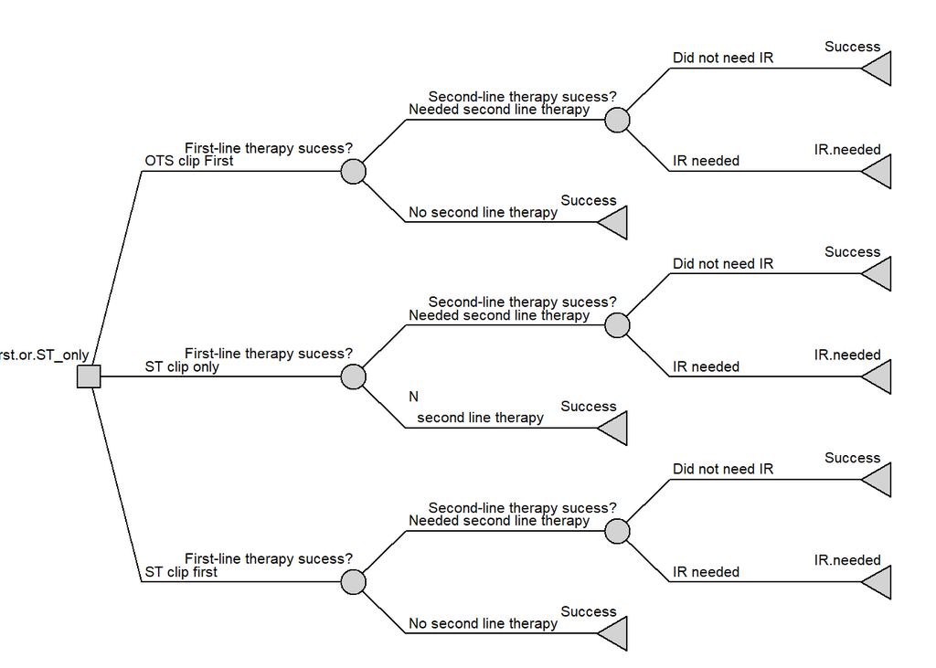

```r
# I like to turn the parameters from my table into  a named list
# Then I can refer to the parameter I want by, e.g., `params$c_OTS`
params <- as.list(t_params$base_case)
names(params) <- t_params$name

#Create root decision node
decision_node <- DecisionNode$new("OTS_first or ST_first or ST_only")


# Create chance nodes for whether first-line therapy was successful in each scenario
chance_node_OTS_first <- ChanceNode$new("First-line therapy sucess?")
chance_node_ST_first <- ChanceNode$new("First-line therapy sucess?")
chance_node_ST_only<- ChanceNode$new("First-line therapy sucess?")

#Create chance nodes for whether second-line therapy was successful in each scenario
chance_node_OTS_then_ST <- ChanceNode$new("Second-line therapy sucess?")
chance_node_ST_then_OTS <- ChanceNode$new("Second-line therapy sucess?")
chance_node_ST_then_ST <- ChanceNode$new("Second-line therapy sucess?")

#Create leaf nodes
# (9 total. "1st line success", "2nd line success", and "IR needed" for each scenario)

leaf_node_OTS_1success <- LeafNode$new("Success", utility = params$q_single_EGD)
leaf_node_OTS_2success <- LeafNode$new("Success", utility = params$q_double_EGD)
leaf_node_OTS_ir_needed <- LeafNode$new("IR needed",  utility = params$q_IR)

leaf_node_ST_first_1success <- LeafNode$new("Success",  utility = params$q_single_EGD)
leaf_node_ST_first_2success <- LeafNode$new("Success",  utility = params$q_double_EGD)
leaf_node_ST_first_ir_needed <- LeafNode$new("IR needed",  utility = params$q_IR)

leaf_node_ST_only_1success <- LeafNode$new("Success",  utility = params$q_single_EGD)
leaf_node_ST_only_2success <- LeafNode$new("Success",  utility = params$q_double_EGD)
leaf_node_ST_only_ir_needed <- LeafNode$new("IR needed",  utility = params$q_IR)


#Create 'actions', paths from your decision node(s).

action_OTS <- Action$new(
  decision_node, chance_node_OTS_first, cost = params$c_EGD_MD + params$c_OTSclip, label = "OTS clip First"
)
action_ST_first <- Action$new(
  decision_node, chance_node_ST_first, cost = params$c_EGD_MD + params$c_STclip, label = "ST clip first"
)
action_ST_only <- Action$new(
  decision_node, chance_node_ST_only, cost = params$c_EGD_MD + params$c_STclip, label = "ST clip only"
)


#Create 'reactions', paths from your chance node(s)
# 12 total:
#  - Reactions for success after first-line therapy
#  - Reactions for failure (rebleed) after first-line therapy
#  - Reactions for success after second-line therapy
#  - Reactions for failure (IR needed) after second-line therapy


#First line success:
reaction_OTS_success <- Reaction$new(
  chance_node_OTS_first, leaf_node_OTS_1success,
  p = 1-params$p_OTSc_rebleed, cost = params$c_hosp_noCC, label = "No second line therapy")

reaction_ST_first_success <- Reaction$new(
  chance_node_ST_first, leaf_node_ST_first_1success,
  p = 1-params$p_ST_rebleed, cost = params$c_hosp_noCC, label = "No second line therapy")

reaction_ST_only_success <- Reaction$new(
  chance_node_ST_only, leaf_node_ST_only_1success,
  p = 1-params$p_ST_rebleed, cost = params$c_hosp_noCC, label = "N
  second line therapy")


#First line failure:
reaction_OTS_failure <- Reaction$new(
  chance_node_OTS_first, chance_node_OTS_then_ST,
  p = params$p_OTSc_rebleed, cost = params$c_EGD_MD+params$c_STclip, label = "Needed second line therapy")

reaction_ST_first_failure <- Reaction$new(
  chance_node_ST_first, chance_node_ST_then_OTS,
  p = params$p_ST_rebleed, cost = params$c_EGD_MD+params$c_OTSclip, label = "Needed second line therapy")

reaction_ST_only_failure <- Reaction$new(
  chance_node_ST_only, chance_node_ST_then_ST,
  p = params$p_ST_rebleed, cost = params$c_EGD_MD+params$c_STclip, label = "Needed second line therapy")

#Second line success:
reaction_OTS_then_ST_success <- Reaction$new(
  chance_node_OTS_then_ST, leaf_node_OTS_2success,
  p = 1-params$p_ST_rpt_IR, cost = params$c_hosp_CC, label = "Did not need IR")

reaction_ST_then_OTS_success <- Reaction$new(
  chance_node_ST_then_OTS, leaf_node_ST_first_2success,
  p = 1-params$p_OTSc_rpt_IR, cost = params$c_hosp_CC, label = "Did not need IR")

reaction_ST_then_ST_success <- Reaction$new(
  chance_node_ST_then_ST, leaf_node_ST_only_2success,
  p = 1-params$p_ST_rpt_IR, cost = params$c_hosp_CC, label = "Did not need IR")

#Second line failure:

reaction_OTS_then_ST_failure <- Reaction$new(
  chance_node_OTS_then_ST, leaf_node_OTS_ir_needed,
  p = params$p_ST_rpt_IR, cost = params$c_IR_MD+params$c_hosp_MCC, label = "IR needed")

reaction_ST_then_OTS_failure <- Reaction$new(
  chance_node_ST_then_OTS, leaf_node_ST_first_ir_needed,
  p = params$p_OTSc_rpt_IR, cost = params$c_IR_MD+params$c_hosp_MCC, label = "IR needed")

reaction_ST_then_ST_failure <- Reaction$new(
  chance_node_ST_then_ST, leaf_node_ST_only_ir_needed,
  p = params$p_ST_rpt_IR, cost = params$c_IR_MD+params$c_hosp_MCC, label = "IR needed")


#Create the tree
DT2 <-DecisionTree$new(
  V = list(decision_node, #verticies (nodes)
           chance_node_OTS_first,
           chance_node_ST_only,
           chance_node_ST_first,
           chance_node_OTS_then_ST,
           chance_node_ST_then_OTS,
           chance_node_ST_then_ST,
            leaf_node_OTS_1success,
            leaf_node_OTS_2success,
            leaf_node_OTS_ir_needed,
            leaf_node_ST_first_1success ,
            leaf_node_ST_first_2success ,
            leaf_node_ST_first_ir_needed ,
            leaf_node_ST_only_1success ,
            leaf_node_ST_only_2success,
            leaf_node_ST_only_ir_needed),


  E = list(action_OTS, #edges (paths between nodes)
           action_ST_only,
           action_ST_first,
           reaction_OTS_success ,
           reaction_ST_first_success ,
           reaction_ST_only_success ,
           reaction_OTS_failure ,
           reaction_ST_first_failure ,
           reaction_ST_only_failure ,
           reaction_OTS_then_ST_success ,
           reaction_ST_then_OTS_success ,
           reaction_ST_then_ST_success ,
           reaction_OTS_then_ST_failure ,
           reaction_ST_then_OTS_failure ,
           reaction_ST_then_ST_failure)
)

# Draw the tree
DT2$draw()
```

```r
# Create table with the expected cost and utility (in QALYs or QALD) of each alternative
DT2_evaluation <- DT2$evaluate() #calculate it
DT2_evaluation |> flextable()
```

| OTS_first.or.ST_first.or.ST_only | Run | Probability | Cost | Benefit | Utility | QALY |
| --- | --- | --- | --- | --- | --- | --- |
| OTS clip First | 1 | 1 | 6,490.388 | 0 | 0.9865357 | 0.9865357 |
| ST clip first | 1 | 1 | 6,297.512 | 0 | 0.9865028 | 0.9865028 |
| ST clip only | 1 | 1 | 6,576.226 | 0 | 0.9860364 | 0.9860364 |

The differences in QALYs experienced in a one-year period is hard to see. We can instead convert the QALYs experienced to lost quality-adjusted life days (QALDs lost). I wrote the code for you; you just need to uncomment it after completing the previous code block.

```r
DT2_evaluation <- DT2_evaluation |>
  mutate(QALD_lost = (1 - QALY)*365)
DT2_evaluation |> flextable()
```

| OTS_first.or.ST_first.or.ST_only | Run | Probability | Cost | Benefit | Utility | QALY | QALD_lost |
| --- | --- | --- | --- | --- | --- | --- | --- |
| OTS clip First | 1 | 1 | 6,490.388 | 0 | 0.9865357 | 0.9865357 | 4.914462 |
| ST clip first | 1 | 1 | 6,297.512 | 0 | 0.9865028 | 0.9865028 | 4.926478 |
| ST clip only | 1 | 1 | 6,576.226 | 0 | 0.9860364 | 0.9860364 | 5.096714 |

Using a willingness to pay threshold of $50,000 per QALY ($137 per QALD), indicate whether each intervention is dominated with strong dominance, Dominated by extended dominant, not preferred, or preferred (exactly one intervention should be preferred). Indicate the ICER for any non-dominated interventions when applicable.

> ST only: strongly dominated by ST first (since it has higher cost than ST first)

In case you’re curious, this is a slightly simplified version of [a paper I published as a PhD student](https://doi.org/10.1016/j.giec.2019.09.004).

# Section 2: Economic evaluation

## 2a Discounting

The vector `costs_by_year` represents costs by year, starting with year 0 (this year, which should not be discounted). Calculate the net present cost with an annual discount rate of 2% and of 5%.

```r
costs_by_year <- c(100, 200, 500, 350, 700) #costs 0, 1, 2, 3, and 4 years into the future

npc_func<- function(r, costs_by_year) {

    npc <- 0

    for (i in 1:5){
      npc<-npc+costs_by_year[i]*(1/(1+r)^i)

    }

    return(npc)

}

npc_2percent <- npc_func(2, costs_by_year) #Calculate the net present cost with a discount rate of 2 percent

npc_5percent <- npc_func(5, costs_by_year) #Calculate the net present cost with a discount rate of 5 percent

npc_2percent
```

```
[1] 81.27572
```

```r
npc_5percent
```

```
[1] 24.89712
```

## 2b Incremental analysis

In this section, we’ll use loops to conduct incremental analysis, the process of identifying dominated strategies and calculating the incremental cost-effectiveness ratios (ICERs) between the remaining non-dominated strategies. Coding this yourself should give you a strong understanding of the concept. Let’s get started!

First, I’ve written the code for you that reads in the data on 9 different strategies we wish to compare (from the params_assign1.xlsx file). For each strategy, we are provided with the estimated QALYs experienced and the estimated cost across three categories: those insurer pays, out-of-pocket costs paid by the patient, and productivity loss.

```r
#No edits needed to this code chunk

#read table from Excel
t_CE <- read_excel('params_assign1.xlsx', sheet = "CEdata")
#Display it nicely
t_CE |>
  flextable() |> #turn into flextable object
  theme_box() |> #Apply a theme for aesthetics
  autofit() #automatically set column widths to reasonable values
```

| Strategy | QALYs | Cost_insurer | Cost_patient | Cost_productivity |
| --- | --- | --- | --- | --- |
| G | 1.21 | 110,000 | 1,080 | 1,318 |
| A | 2.03 | 120,000 | 10,800 | 2,212 |
| B | 3.04 | 747,000 | 224,100 | 3,070 |
| I | 3.43 | 504,000 | 5,940 | 3,430 |
| E | 5.03 | 414,000 | 124,200 | 4,828 |
| C | 5.49 | 594,000 | 64,800 | 5,105 |
| H | 5.64 | 310,000 | 23,760 | 5,414 |
| F | 6.10 | 324,000 | 81,000 | 5,396 |
| D | 8.39 | 648,000 | 110,880 | 8,641 |

**Insurer perspective:** In this code chunk, you’ll calculate the cost-effectiveness from the insurer’s perspective (only including costs in the `Cost_insurer` column). First, we detect any strategies that are dominated by strong dominance, then, we check for costs that are dominated by extended dominance. Lastly, we calculate the ICERs between all non-dominated interventions. I’ve provided some of the code, but you’ll need to complete it.

```r
#Create table with columns "strategy", "QALYs", and "Cost", where cost is the Cost_insurer. We'll add two columns, one for whether the strategy is dominated and another for putting the ICERS for non-dominated interventions
t_ICERS <- data.frame(
  Strategy = t_CE$Strategy,
  QALYs = t_CE$QALYs,
  Cost = t_CE$Cost_insurer,
  Dominated = "No",
  ICER = 0.0
)

#Sort t_ICERS ascending by QALYs (from low to high)
t_ICERS <-t_ICERS[order(t_ICERS$QALYs),]
#We need to reset the row index names
row.names(t_ICERS) <- NULL


### REMOVE INTERVENTIONS DOMINATED BY STRONG DOMINANCE
# We have to loop through rows to identify dominated strategies. If we find any,
#  we need to look through them again in case there are more. We will use a while loop.
continue = T #If this is still T at the end of the while loop, it will restart
while(continue){
  continue = F #if no dominated strategies found in for loop below, exit while loop
  #Get the row index for all rows that aren't dominated
  idx_nondom_rows <- as.numeric(rownames(t_ICERS[t_ICERS$Dominated =="No",]))
  #Get number of non-dominated rows
  n_nondom <- length(t_ICERS[t_ICERS$Dominated =="No",])

  #LOOP over each row starting with the second non-dominated row
  # compare it to previous non-dominated row to see if it is dominated
  for (i in 2:n_nondom){
    row_this <- idx_nondom_rows[i] #index of the current row
    row_last <- idx_nondom_rows[i-1] #index of last undominated row

    if ((t_ICERS$Cost[row_this] < t_ICERS$Cost[row_last])){ #Replace 'F' with the correct condition
      #Strategy in row t_ICERS[row_last, ] is strong dominated
      # set Dominated value to "Strong"
      # set ICER value to NA
      # set continue to T so that we do another loop
      t_ICERS$Dominated[row_last]<-"Strong"
      t_ICERS$ICER[row_last]<-NA
      continue<-T

    }

  }
}

### REMOVE INTERVENTIONS DOMINATED BY EXTENDED DOMINANCE
# We have to loop through rows to identify dominated strategies. If we find any,
#  we need to look through them again in case there are more. We will use a while loop.
continue = T
while(continue){
  continue = F #if no dominated strategies are found, exit loop
  #Get the row index for all rows that aren't dominated
  idx_nondom_rows <- as.numeric(rownames(t_ICERS[t_ICERS$Dominated=="No",]))
  #Get number of nondom rows
  n_nondom <-length(t_ICERS[t_ICERS$Dominated=="No",]) - 1
  #LOOP over each row starting with the second non-dominated row
  # compare it to previous non-dominated row to see if it is dominated

  for (i in 2:n_nondom){
    row_this <- idx_nondom_rows[i] #index of the current row
    row_last <- idx_nondom_rows[i-1] #index of last undominated row

    #Calculate ICER for row_this compared to last non-dominated row
    # Put it in t_ICERS[row_this,"ICER"]

    t_ICERS$ICER[row_this] <- (t_ICERS$Cost[row_this]-t_ICERS$Cost[row_last])/(t_ICERS$QALYs[row_this] - t_ICERS$QALYs[row_last])


   print(t_ICERS$Cost[row_this])
   print(t_ICERS$QALYs[row_this])

    if(t_ICERS$ICER[row_this]<t_ICERS$ICER[row_last]){ #REPLACE F WITH THE CORRECT CONDITION
      #Strategy in row t_ICERS[row_last, ] is extended dominated
      # set Dominated value to "Extended"
      # set ICER value to NA
      # set continue to T so that we do another loop

      t_ICERS$Dominated[row_last]<-'Extended'
      t_ICERS$ICER[row_last]<-NA
      continue<-T

    }
  }
}
```

```
[1] 120000
[1] 2.03
[1] 310000
[1] 5.64
[1] 324000
[1] 6.1
[1] 120000
[1] 2.03
[1] 324000
[1] 6.1
[1] 648000
[1] 8.39
```

```r
#Display it nicely
t_ICERS |>
  flextable() |> #turn into flextable object
  theme_box() |> #Apply a theme for aesthetics
  autofit() #automatically set column widths to reasonable values
```

| Strategy | QALYs | Cost | Dominated | ICER |
| --- | --- | --- | --- | --- |
| G | 1.21 | 110,000 | No | 0.00 |
| A | 2.03 | 120,000 | No | 12,195.12 |
| B | 3.04 | 747,000 | Strong |  |
| I | 3.43 | 504,000 | Strong |  |
| E | 5.03 | 414,000 | Strong |  |
| C | 5.49 | 594,000 | Strong |  |
| H | 5.64 | 310,000 | Extended |  |
| F | 6.10 | 324,000 | No | 50,122.85 |
| D | 8.39 | 648,000 | No | 141,484.72 |

**Function-ize it:** The following code chunk contains the shell of a function that takes three vectors (strategy_name, cost, and QALY), puts them into a table called t_ICERS, does calculations, and then returns the table with ICER and dominated columns added. Complete the funciton by copying and pasting code from the previous code chunk

```r
#INPUT: 3 equal-length vectors strategy_name, cost, and QALYs
#OUTPUT: A data.frame with a column for each of the input vectors, plus "Dominated" and "ICER" columns
generate_ICER_table <- function(strategy_name, cost, QALYs){
  t_ICERS <- data.frame(
  Strategy = strategy_name,
  QALYs = QALYs,
  Cost = cost,
  Dominated = "No",
  ICER = 0.0)

  #Sort t_ICERS ascending by QALYs (from low to high)
t_ICERS <-t_ICERS[order(t_ICERS$QALYs),]
#We need to reset the row index names
row.names(t_ICERS) <- NULL


### REMOVE INTERVENTIONS DOMINATED BY STRONG DOMINANCE
# We have to loop through rows to identify dominated strategies. If we find any,
#  we need to look through them again in case there are more. We will use a while loop.
continue = T #If this is still T at the end of the while loop, it will restart
while(continue){
  continue = F #if no dominated strategies found in for loop below, exit while loop
  #Get the row index for all rows that aren't dominated
  idx_nondom_rows <- as.numeric(rownames(t_ICERS[t_ICERS$Dominated =="No",]))
  #Get number of non-dominated rows
  n_nondom <- length(t_ICERS[t_ICERS$Dominated =="No",])

  #LOOP over each row starting with the second non-dominated row
  # compare it to previous non-dominated row to see if it is dominated
  for (i in 2:n_nondom){
    row_this <- idx_nondom_rows[i] #index of the current row
    row_last <- idx_nondom_rows[i-1] #index of last undominated row

    if ((t_ICERS$Cost[row_this] < t_ICERS$Cost[row_last])){ #Replace 'F' with the correct condition
      #Strategy in row t_ICERS[row_last, ] is strong dominated
      # set Dominated value to "Strong"
      # set ICER value to NA
      # set continue to T so that we do another loop
      t_ICERS$Dominated[row_last]<-"Strong"
      t_ICERS$ICER[row_last]<-NA
      continue<-T

    }

  }
}

### REMOVE INTERVENTIONS DOMINATED BY EXTENDED DOMINANCE
# We have to loop through rows to identify dominated strategies. If we find any,
#  we need to look through them again in case there are more. We will use a while loop.
continue = T
while(continue){
  continue = F #if no dominated strategies are found, exit loop
  #Get the row index for all rows that aren't dominated
  idx_nondom_rows <- as.numeric(rownames(t_ICERS[t_ICERS$Dominated=="No",]))
  #Get number of nondom rows
  n_nondom <-length(t_ICERS[t_ICERS$Dominated=="No",]) - 1
  #LOOP over each row starting with the second non-dominated row
  # compare it to previous non-dominated row to see if it is dominated

  for (i in 2:n_nondom){
    row_this <- idx_nondom_rows[i] #index of the current row
    row_last <- idx_nondom_rows[i-1] #index of last undominated row

    #Calculate ICER for row_this compared to last non-dominated row
    # Put it in t_ICERS[row_this,"ICER"]

    t_ICERS$ICER[row_this] <- (t_ICERS$Cost[row_this]-t_ICERS$Cost[row_last])/(t_ICERS$QALYs[row_this] - t_ICERS$QALYs[row_last])


   print(t_ICERS$Cost[row_this])
   print(t_ICERS$QALYs[row_this])

    if(t_ICERS$ICER[row_this]<t_ICERS$ICER[row_last]){ #REPLACE F WITH THE CORRECT CONDITION
      #Strategy in row t_ICERS[row_last, ] is extended dominated
      # set Dominated value to "Extended"
      # set ICER value to NA
      # set continue to T so that we do another loop

      t_ICERS$Dominated[row_last]<-'Extended'
      t_ICERS$ICER[row_last]<-NA
      continue<-T

    }
  }
}


  return(t_ICERS)
}
```

**Other perspectives:** using the function above, complete the incremental analysis from three cost perspectives:

- **Insurer:** same as above
- **Healthcare costs** includes insurer and patient out-of-pocket costs
- **Societal:** healthcare costs plus productivity loss

```r
t_ICER_insurer <- generate_ICER_table(t_CE$Strategy, t_CE$Cost_insurer, t_CE$QALYs)
```

```
[1] 120000
[1] 2.03
[1] 310000
[1] 5.64
[1] 324000
[1] 6.1
[1] 120000
[1] 2.03
[1] 324000
[1] 6.1
[1] 648000
[1] 8.39
```

```r
t_ICER_healthcare_cost <- generate_ICER_table(t_CE$Strategy, (t_CE$Cost_insurer + t_CE$Cost_patient) , t_CE$QALYs)
```

```
[1] 130800
[1] 2.03
[1] 509940
[1] 3.43
[1] 538200
[1] 5.03
[1] 130800
[1] 2.03
[1] 538200
[1] 5.03
[1] 658800
[1] 5.49
```

```r
t_ICER_societal <- generate_ICER_table(t_CE$Strategy, (t_CE$Cost_insurer + t_CE$Cost_insurer+t_CE$Cost_productivity), t_CE$QALYs)
```

```
[1] 242212
[1] 2.03
[1] 625414
[1] 5.64
[1] 653396
[1] 6.1
[1] 242212
[1] 2.03
[1] 653396
[1] 6.1
[1] 1304641
[1] 8.39
```

```r
#Display them nicely

#INSURER PERSPECTIVE
t_ICER_insurer |>
  flextable() |> #turn into flextable object
  theme_box() |> #Apply a theme for aesthetics
  autofit() #automatically set column widths to reasonable values
```

| Strategy | QALYs | Cost | Dominated | ICER |
| --- | --- | --- | --- | --- |
| G | 1.21 | 110,000 | No | 0.00 |
| A | 2.03 | 120,000 | No | 12,195.12 |
| B | 3.04 | 747,000 | Strong |  |
| I | 3.43 | 504,000 | Strong |  |
| E | 5.03 | 414,000 | Strong |  |
| C | 5.49 | 594,000 | Strong |  |
| H | 5.64 | 310,000 | Extended |  |
| F | 6.10 | 324,000 | No | 50,122.85 |
| D | 8.39 | 648,000 | No | 141,484.72 |

```r
#HEALTHCARE COST PERSPECTIVE
t_ICER_healthcare_cost |>
  flextable() |> #turn into flextable object
  theme_box() |> #Apply a theme for aesthetics
  autofit() #automatically set column widths to reasonable values
```

| Strategy | QALYs | Cost | Dominated | ICER |
| --- | --- | --- | --- | --- |
| G | 1.21 | 111,080 | No | 0.00 |
| A | 2.03 | 130,800 | No | 24,048.78 |
| B | 3.04 | 971,100 | Strong |  |
| I | 3.43 | 509,940 | Extended |  |
| E | 5.03 | 538,200 | No | 135,800.00 |
| C | 5.49 | 658,800 | No | 262,173.91 |
| H | 5.64 | 333,760 | No | 0.00 |
| F | 6.10 | 405,000 | No | 0.00 |
| D | 8.39 | 758,880 | No | 0.00 |

```r
#SOCIETAL PERSPECTIVE
t_ICER_societal |>
  flextable() |> #turn into flextable object
  theme_box() |> #Apply a theme for aesthetics
  autofit() #automatically set column widths to reasonable values
```

| Strategy | QALYs | Cost | Dominated | ICER |
| --- | --- | --- | --- | --- |
| G | 1.21 | 221,318 | No | 0.00 |
| A | 2.03 | 242,212 | No | 25,480.49 |
| B | 3.04 | 1,497,070 | Strong |  |
| I | 3.43 | 1,011,430 | Strong |  |
| E | 5.03 | 832,828 | Strong |  |
| C | 5.49 | 1,193,105 | Strong |  |
| H | 5.64 | 625,414 | Extended |  |
| F | 6.10 | 653,396 | No | 101,028.01 |
| D | 8.39 | 1,304,641 | No | 284,386.46 |

## 2c Identifying maximum net monetary benefit

Calculate NMB at a range of WTP thresholds from a societal perspective, and then plot them.

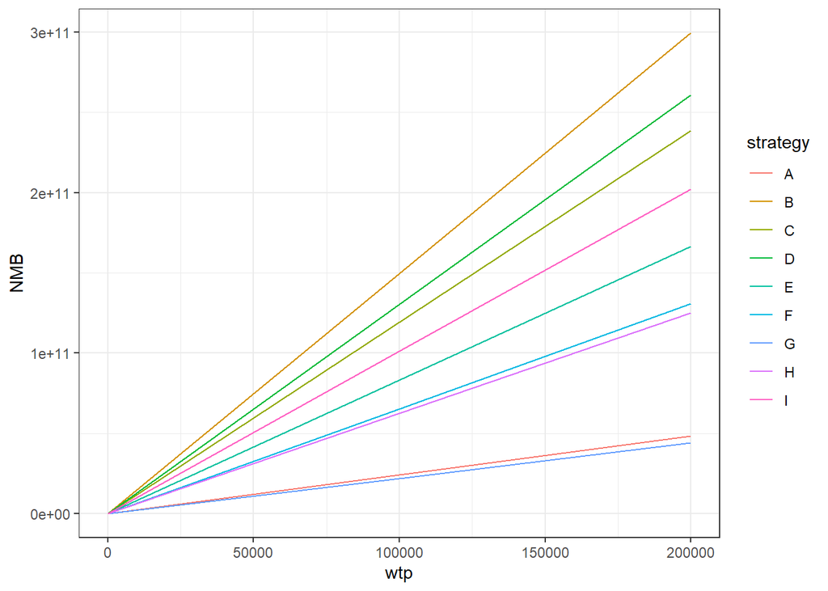

```r
#Vector of willingness-to-pay values for which to calcualte NMB
wtp_vec = seq(0, 2.5e5, 1e5)

#Calcualte societal cost and add it as a column to the t_CE table
t_CE$cost_societal <- t_CE$Cost_insurer + t_CE$Cost_insurer+t_CE$Cost_productivity

#Create a table to contain the NMB calculations
t_nmb_plot <- data.frame(
  strategy = rep(t_CE$Strategy, each = length(wtp_vec)),
  wtp = rep(wtp_vec, times = nrow(t_CE)),
  cost = rep(t_CE$cost_societal, each = length(wtp_vec)),
  QALYs = rep(t_CE$QALYs, each = length(wtp_vec))
)

#Calculate NM
t_nmb_plot$NMB <- t_nmb_plot$QALYs + t_nmb_plot$cost * t_nmb_plot$wtp


#Plot it with ggplot
ggplot(t_nmb_plot, aes(x = wtp, y = NMB, color = strategy))+
  geom_line()
```

# Last two questions

Fin.